# Creating and applying bespoke color schemes

Cara Thompson

24/01/2022

### “Ooh look, a `ggplot()` plot!”

In creating polished reports and visualizations for our clients, that is never the reaction we’re hoping for. Sure, the “I didn’t know you could do that in R!” reaction is always fun, but what we want above all is for the plots and tables to blend in seamlessly with the rest of the client’s aesthetic. Picking a color scheme that ties in with a client’s brand or that evokes the subject matter behind the data is what allows the plot to contribute to, rather than detract from, the main story the client is seeking to tell.

This post explores how we go about choosing an appropriate color scheme and how to create `scale_fill/color_discrete/continous()` to align all plots with that colour scheme, using the example of our recent project with Colibri Consulting.

## Step 1: Decide what colors to use

In the case of this project, our client had a logo with two colors. She was able to give us the hex codes for those colours, which was handy, but there are plenty of online tools to help you pick out the hex colours in an image or even in a website. My personal go-to is [Color Picker Online](https://imagecolorpicker.com/en) which does what it says on the tin: it allows you to pick out different colors from an image or a website, and provides you with their hex codes.

## Step 2: See what those colors look like when used for dataviz

There are plenty of datasets around that can be used to create plots to get a feel for the color schemes we’ll be using. The `penguins` set from `{palmerpenguins}` is one of my favorites: it contains both continuous data (e.g. flipper lengths) and categorical data (e.g. species), along with some NAs. And, because of the way the flipper and bill lengths group together into clusters, it’s a great way of seeing how the colors highlight the different clusters of points.

Let’s put together a basic plot that we can then apply our color schemes to:

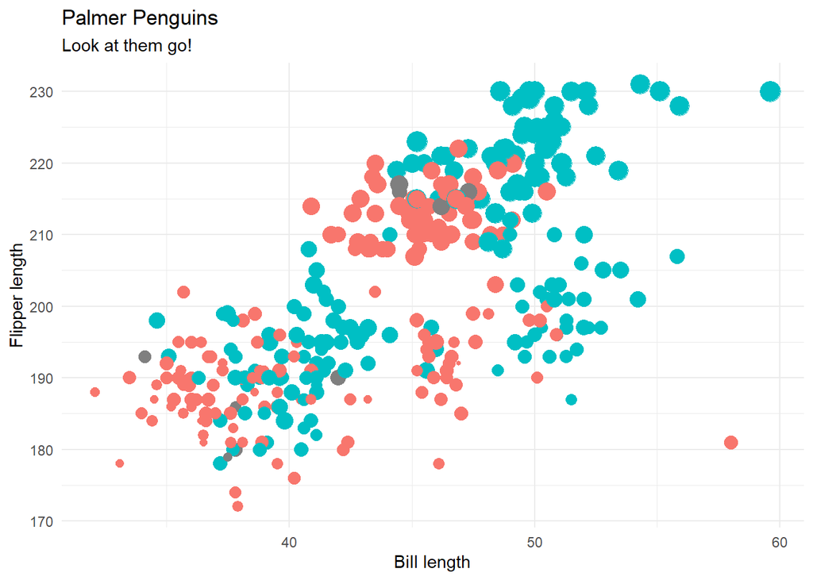

```r
categorical_penguins <-
  palmerpenguins::penguins %>%
  ggplot() +
  geom_point(aes(x = bill_length_mm, y = flipper_length_mm,
                 color = sex, size = body_mass_g),
             show.legend = F) +
  labs(title = "Palmer Penguins",
       subtitle = "Look at them go!",
       x = "Bill length",
       y = "Flipper length") +
  theme_minimal()

categorical_penguins
```

I had an inkling this might happen, but when I created a plot using the colors from the client’s logo, the problem became clear: the green “popped” way more than the purple, meaning that whichever group ended up being green in our data viz would be highlighted to the detriment of the purple group.

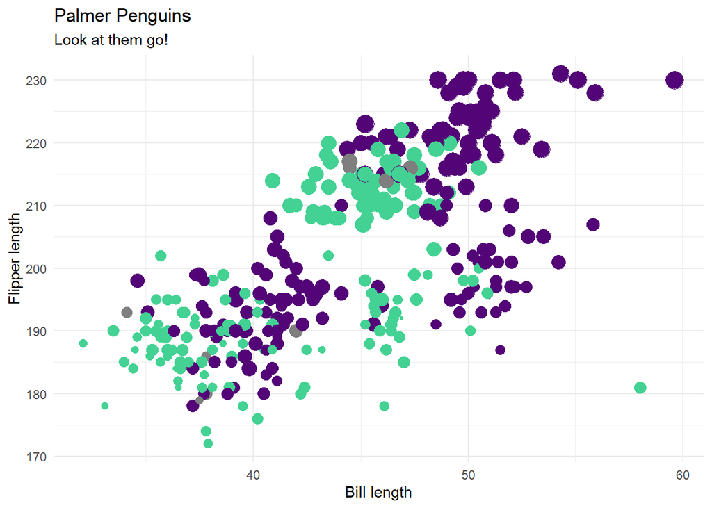

```r
categorical_penguins +
  scale_color_manual(values = c("#43d293", "#530577"))
```

This wasn’t the effect we were going for, so some tweaking was required.

My first step was to blend together the two colours, to see if we could get a “muted” green that tied in nicely with the original colors. I created `{monochromer}` for exactly this purpose:

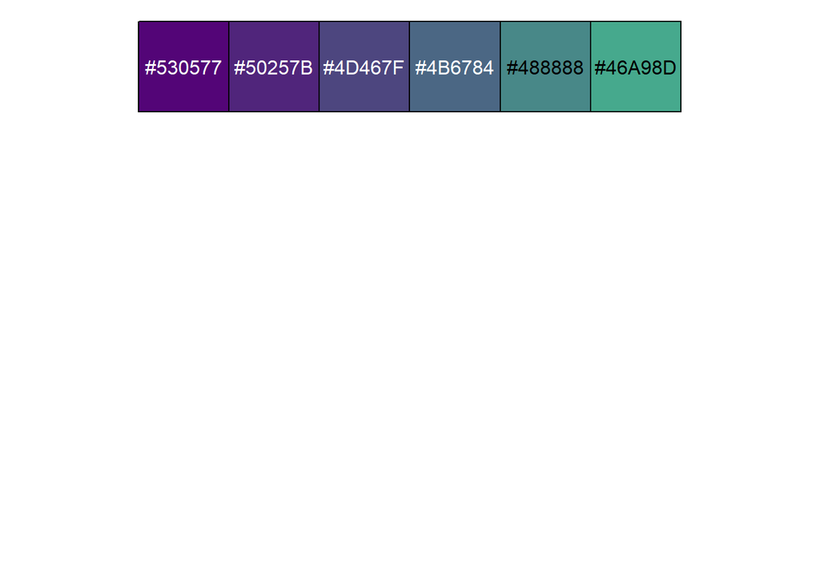

```
## [1] "#530577" "#50257B" "#4D467F" "#4B6784" "#488888" "#46A98D"
```

```r
monochromeR::generate_palette("#530577", modification = "blend",
                              blend_colour = "#43d293",
                              n_colours = 6, view_palette = T)
```

The last color in this palette is the green with a touch of purple. After some experimenting, it was still a bit too bright, so, in discussion with the client, we decided to go for a purple that was one step towards the green, and green that was one step towards the purple as the two main colors to base the palettes on.

Here’s the penguin plot again with those two colors. It looks much more balanced!

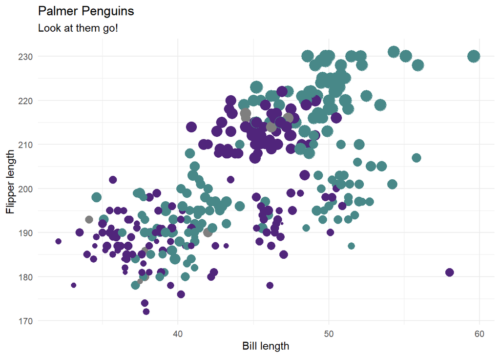

```r
categorical_penguins +
  scale_color_manual(values = c("#50257B", "#488888"))
```

## Step 3: Check the colors work for people with different types of color vision

Creating plots that work for as many readers as possible is important. Claire D. McWhite and Claus O. Wilke have made it easy for us #rstats users to check this with `{colorblindr}`, a package that simulates how plots look to readers with different color perception deficiencies.

```r
colorblindr::cvd_grid(

  categorical_penguins +
    scale_color_manual(values = c("#50257B", "#488888"))

)
```

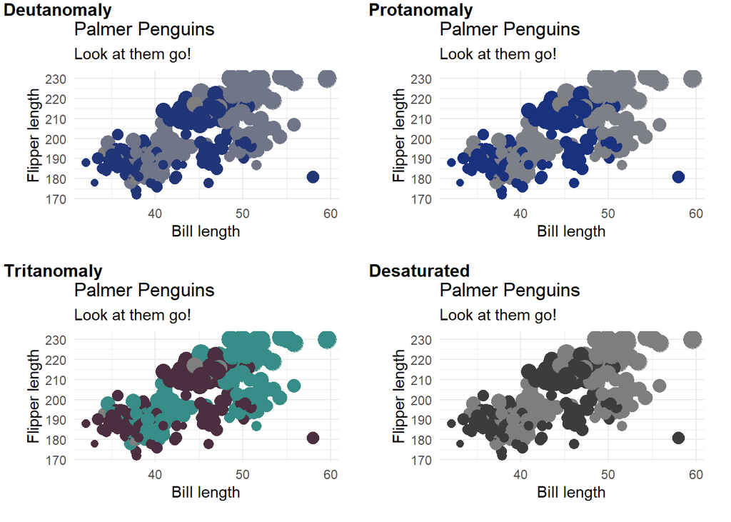

The two main colors seem to come across well, but the NAs were getting lost in all but one of the plots. To rectify that, I created an NA color which was a faded version of the middle color between our two main colors:

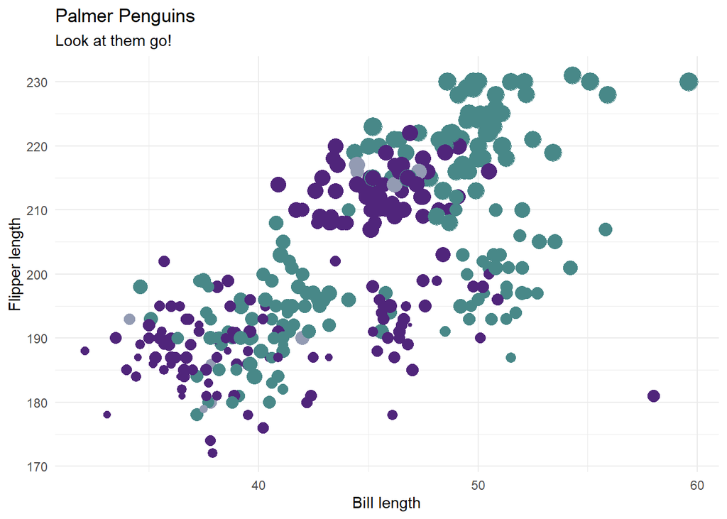

```r
middle_col <- c(monochromeR::generate_palette("#50257B",
                                              modification = "blend",
                                              blend_colour = "#488888",
                                              n_colours = 4), "#488888")[3]

NA_col <- monochromeR::generate_palette(middle_col,
                                        modification = "go_both_ways",
                                        n_colours = 5)[2]


categorical_penguins +
  scale_color_manual(values = c("#50257B", "#488888"), na.value = NA_col)
```

```r
colorblindr::cvd_grid(

  categorical_penguins +
    scale_color_manual(values = c("#50257B", "#488888"), na.value = NA_col)

)
```

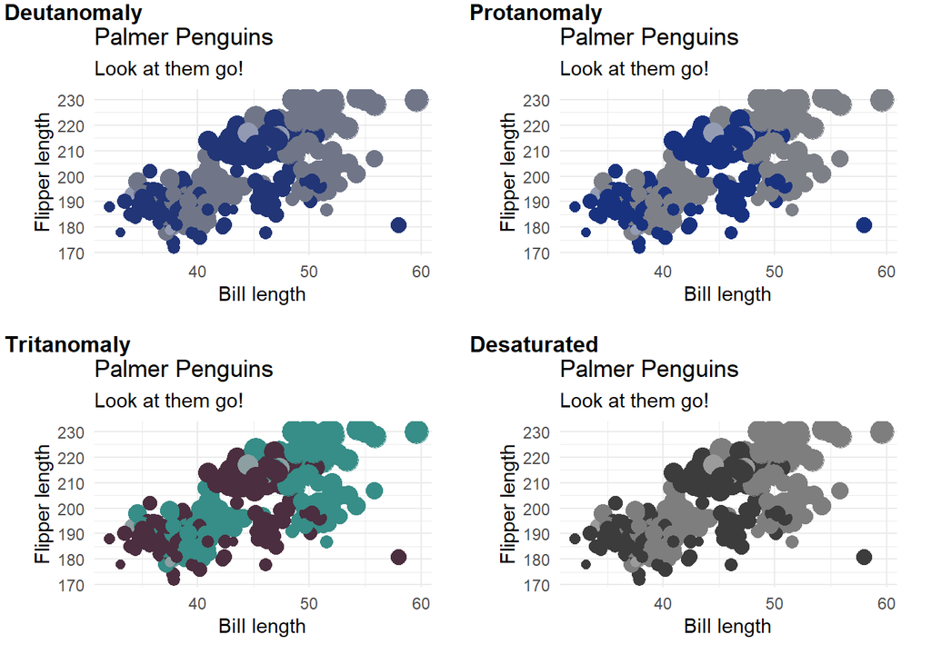

The are a different color to the two main colours in all four of the plots - mission accomplished!

## Step 4: Create color/fill scales

In this project, we’ll be creating a **lot** of plots! We have plots some comparing two groups, some requiring more colors, and some using continuous data. We don’t want to be adding those colors manually every time! Instead, let’s create a few palettes we can call upon. First we need to get our anchors at either end of the palettes. We already have our “Purple-to-Green” anchor colors, but we also needed an all-purple palette and an all-green palette, so we needed a light purple and a light green to fade to:

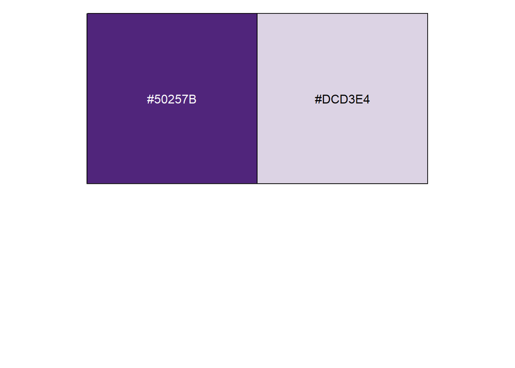

```
## [1] "#50257B" "#DCD3E4"
```

```r
# Purple extremes
monochromeR::generate_palette("#50257B",
                              modification = "go_lighter",
                              n_colours = 2, view_palette = T)
```

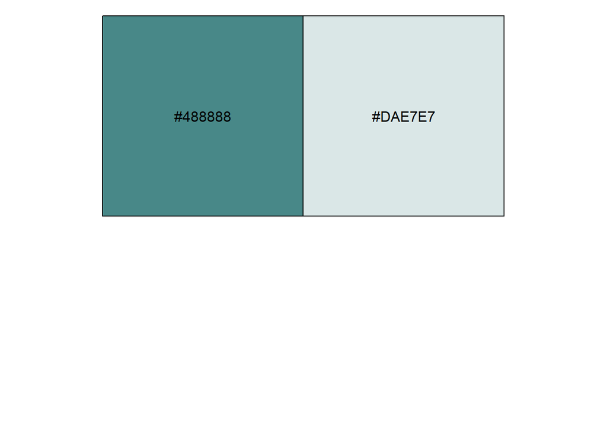

```
## [1] "#488888" "#DAE7E7"
```

```r
# Green extremes
monochromeR::generate_palette("#488888",
                              modification = "go_lighter",
                              n_colours = 2, view_palette = T)
```

Next, we use those values to create palettes that we call upon within `scale_color/fill` functions. Note the `NA_col` applied to `na_values` from earlier in this post.

```r
colibri_pal <- function(palette = "Main",
                        reverse = FALSE,
                        ...) {

  colibri_palettes <- list(
    "Main" = c("#50257B", "#488888"),
    "Purple" =  c("#50257B", "#DCD3E4"),
    "Green" = c("#488888", "#DAE7E7")
  )

  pal <- colibri_palettes[[palette]]

  if (reverse)
    pal <- rev(pal)

  grDevices::colorRampPalette(pal, ...)

}

# Discrete scales
scale_color_colibri_discrete <-
  function(palette = "Main",
           reverse = FALSE,
           ...) {
    pal <- colibri_pal(palette = palette, reverse = reverse)

    ggplot2::discrete_scale("color", pal,
                            na.value = NA_col,
                            palette = pal, ...)

  }

scale_fill_colibri_discrete <-
  function(palette = "Main",
           reverse = FALSE,
           ...) {
    pal <- colibri_pal(palette = palette, reverse = reverse)

    ggplot2::discrete_scale("color", pal,
                            na.value = NA_col,
                            palette = pal, ...)

  }

# Continuous scales
scale_color_colibri_continuous <-
  function(palette = "Main",
           reverse = FALSE,
           ...) {
    pal <- colibri_pal(palette = palette, reverse = reverse)

    ggplot2::scale_color_gradientn(colors = pal(256),
                                   na.value = NA_col,
                                   ...)

  }

scale_fill_colibri_continuous <-
  function(palette = "Main",
           reverse = FALSE,
           ...) {
    pal <- colibri_pal(palette = palette, reverse = reverse)

    ggplot2::scale_color_gradientn(colors = pal(256),
                                   na.value = NA_col,
                                   ...)

  }
```

## Step 5: Align the text and grid lines with the color scheme for a more polished look

```r
light_text_col <- NA_col

dark_text_col <- monochromeR::generate_palette(middle_col,
                                               modification = "go_both_ways",
                                               n_colours = 5)[4]

light_col <- monochromeR::generate_palette(middle_col,
                                           modification = "go_both_ways",
                                           n_colours = 5)[1]
```

We can then use these to modify `theme_minimal()`:

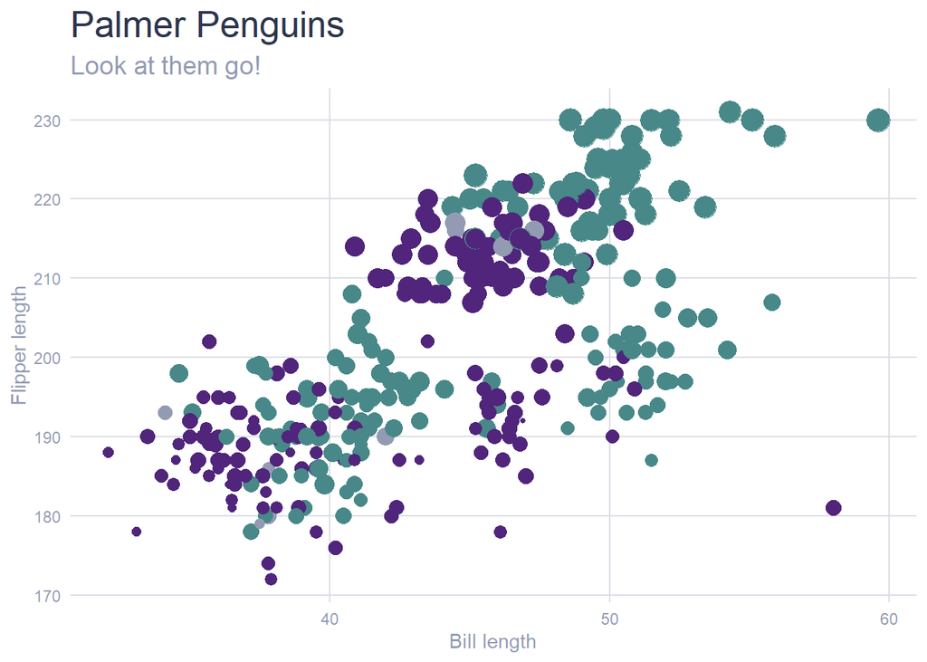

```r
categorical_penguins +
  scale_fill_colibri_discrete("Main") +
  theme_minimal() +
  theme(panel.grid.minor = element_blank(),
        panel.grid.major = element_line(color = light_col),
        text = element_text(color = light_text_col),
        plot.subtitle = element_text(size = 14, color = light_text_col),
        axis.ticks = element_blank(),
        axis.text = element_text(color = light_text_col),
        plot.title = element_text(color = dark_text_col, size = 20))
```

## Bringing it all together

Here are some plots with continuous color scales, making use of all the steps above.

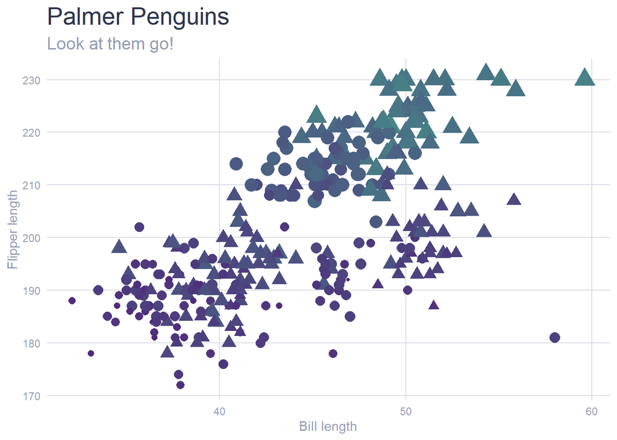

```r
continuous_penguins +
  scale_color_colibri_continuous()
```

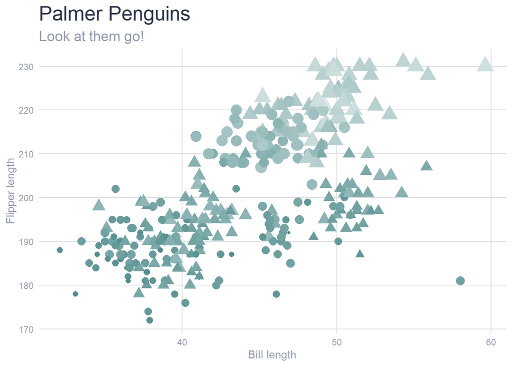

```r
continuous_penguins +
  scale_color_colibri_continuous("Green")
```

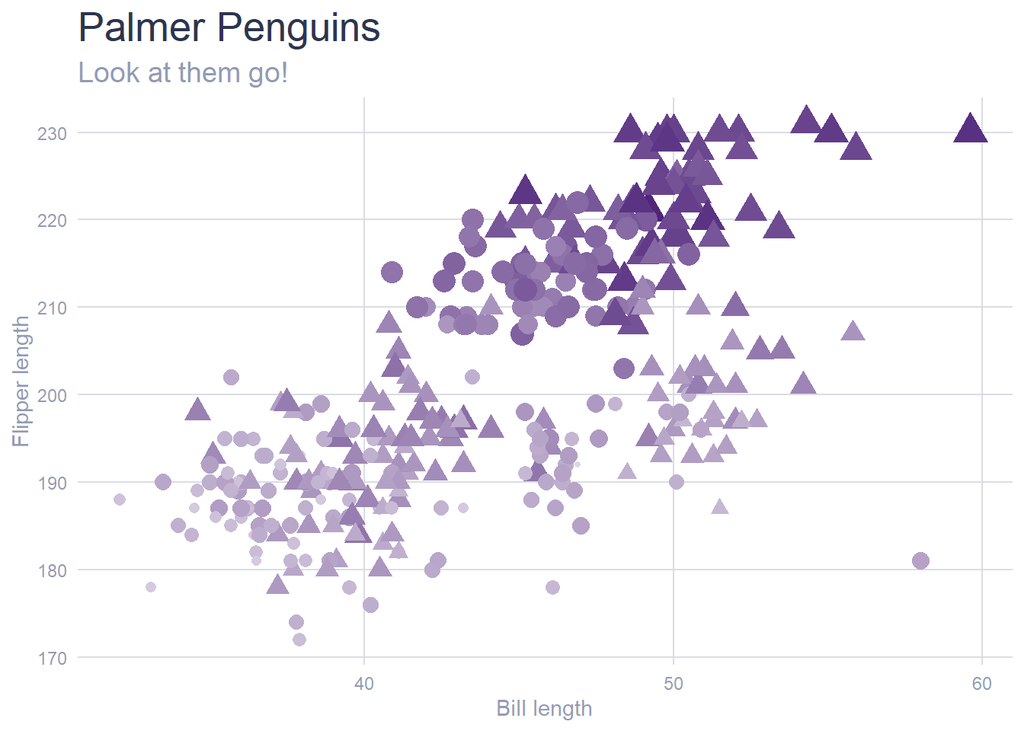

```r
continuous_penguins +
  scale_color_colibri_continuous("Purple", reverse = T)
```

There are other trick to move further away from the `ggplot()` defaults with fonts, margins, line heights, etc. But there’s only so much we can cover in one post! We’ll get to those another day.

In the meantime, happy plotting!